# Predicting Red List categories reveals hidden extinction risk in one of the world’s most diverse freshwater invertebrate families

This script in R markdown format reproduces all analyses for the manuscript about Hydrobiidae extinction risk. The separate file *data_preparation.Rmd* shows how all input data were generated.

## Methods

### Load packages

We need a number of packages. All except the IUCNN package are on cran. To install IUCNN, follow the instructions on the [IUCNN github page](https://github.com/IUCNN/IUCNN). In addition to installing the R package, we need a python installation. The most robust way is to setup a miniconda environment as described on the IUCNN github page.

```r
# Packages for estimating extinction risk
library(reticulate)
library(IUCNN)

# Activate conda environment
use_condaenv("iucnn")

# Packages for EDGE scores
library(phylobase)

# Packages for plotting results
library(sf)
library(rnaturalearth)
library(ape)
library(picante)
library(phytools)
library(plotrix)
library(ggplot2)
library(ggalluvial)
library(ggridges)
library(patchwork)
library(vioplot)
library(viridisLite)
```

### Helper functions

Load some helper functions. These assist in reshaping some model output for plotting, generate some plots to keep this script here a bit more organized, and the R functions by [Grumbs et al. 2023](https://journals.plos.org/plosbiology/article?id=10.1371/journal.pbio.3001991) for the EDGE2 protocol.

```r
source(file.path("helper_functions.R"))
```

```r
# No scientific notion (e.g. 1e6) for plots
options(scipen = 999)

# Safe default plotting parameter to reset them
par_default <- par(no.readonly = TRUE)

# Set seed
set.seed(123)
```

### Load data

We load the species-level data generated by the *data_preparation.Rmd* script. These data include:

- IUCN categories (LC, NT, VU, EN, CR, DD, or NE) for all 876 species `iucn_labels`
- 23 predictor variables (with categorical predictors, such as habitat type, one-hot encoded) `features`
- Means and standard deviations of the continuous predictors used for z-standardization during model training `feature_stats`

The latter are required to reverse the z-standardization and recover meaningful values for the x-axes of the effect plots.

```r
iucn_labels <- read.table(file.path("..", "IUCNN_input",
                                    "iucn_labels.txt"),
                          header = TRUE, sep = "\t")
features <- read.table(file.path("..", "IUCNN_input",
                                 "features.txt"),
                       header = TRUE, sep = "\t")
feature_stats <- read.table(file.path("..", "IUCNN_input",
                                      "feature_stats.txt"),
                            header = TRUE, sep = "\t")
```

Additionally, we need some additional data objects for recreating the figures. These are:

- Geographic coordinates of the populations `coords`
- GIS shapefile of freshwater ecoregions `ecoregions`
- Subfamily assignment of the species `systematic`
- Single taxonomically augmented phylogeny including all 876 species `tree`
- 1000 taxonomically augmented phylogenies `trees_1000`
- Literature data of percentage threatened evolutionary phylogenetic diversity for vertebrates ([Grumbs et al. 2024](https://www.nature.com/articles/s41467-024-45119-z)) and plants ([Forest et al. 2026](https://www.science.org/doi/10.1126/science.adz0773)) `threatened_pd`

```r
# Objects for maps in Figure 4
coords <- read.table(file.path("..", "raw_data", "all_points.csv"),
                     header = TRUE, sep = ",")

ecoregions <- st_read(file.path("..", "raw_data",
                               "freshwater_ecoregions",
                               "ecoregions.shp"),
                      quiet = TRUE)


# Objects for phylogeny in Figure 5
systematic <- read.table(file.path("..", "raw_data", "systematics.csv"),
                       header = TRUE, sep = ",")

tree <- read.tree(file.path("..", "raw_data",
                            "Hydrobiidae_tacted.newick.reproduce.tre"))



# 1000 augmented phylogenies for EDGE calculation
trees_1000 <- readRDS(file.path("..", "raw_data", "tree_distribution",
                                "trees.rds"))


# Threatened phylogenetic diversity of selected plant and animal groups
# (Grump et al. 2024; Forest et al. 2026)
threatened_pd <- read.table(file.path("..", "Forest_et_al_2026",
                                      "perc_thrPD.csv"),
                            header = TRUE, sep = ",")
```

### Prepare model data

We split out input data into a training dataset `iucn_labels_train`, which are all species that are not DD or NE and their features `features_train`. Moreover, we subset the features of the unassessed species to later predict their extinction risk category `features_pred`.

```r
train_idx <- iucn_labels$IUCN %notin% c("NE", "DD")

iucn_labels_train <- iucn_labels[train_idx, ]
features_train <- features[train_idx, ]
features_pred <- features[!train_idx, ]
```

Next, we use the `IUCN::iucnn_prepare_labels` function to prepare the labelled training data. The `level = "detail"` will generate training data coded for all five IUCN categories while the `level = "broad"` groups LC and NT species into the *Not Threatened* class and VU, EN, and CR species into the *Threatened* class.

```r
labels_train_5 <- iucnn_prepare_labels(x = iucn_labels_train,
                                       y = features_train,
                                       labels = "IUCN",
                                       level = "detail")

labels_train_2 <- iucnn_prepare_labels(x = iucn_labels_train,
                                       y = features_train,
                                       labels = "IUCN",
                                       level = "broad")
```

### Model training

We used a fully connected neural network to run a classification model (default nn-class option in IUCNN), as initial trials with the implemented regression model (nn-reg) resulted in lower accuracy. The model training adhered to a five-fold cross-validation methodology (`cv_fold = 5`), wherein the dataset was randomly partitioned five times into 80% training and 20% validation subsets. We specify a neural network architectures with two layers with 20 and 10 neurons, respectively (`n_layers = "20_10"`), and a dropout rate of 0.2. Class weighting was employed during training to address imbalance among threat categories.

We create two folders (*5_class* and *2-class*) where the the neural network are safed.

```r
path_models <- file.path("..", "IUCNN_fit")
dir.create(path = path_models, showWarnings = FALSE)
dir_class_5 <- file.path(path_models, "5_class")
dir_class_2 <- file.path(path_models, "2_class")
```

#### Training the IUCNN model for all five IUCN categories.

```r
# Delete previous model run (in case that it exists)
unlink(dir_class_5, recursive = TRUE)

model_5 <- iucnn_train_model(x = features_train,
                            lab = labels_train_5,
                            path_to_output = dir_class_5,
                            cv_fold = 5,
                            max_epochs = 5000,
                            patience = 2000,
                            n_layers = "20_10",
                            dropout_rate = 0.2,
                            seed = 123,
                            balance_classes = TRUE,
                            optimizer_args = list(learning_rate = 1e-4))
```

#### Training the IUCNN model for the binary *Not Threatened* and *Threatened* classes.

```r
# Delete previous model run (in case that it exists)
unlink(dir_class_2, recursive = TRUE)

model_2 <- iucnn_train_model(x = features_train,
                             lab = labels_train_2,
                             path_to_output = dir_class_2,
                             cv_fold = 5,
                             max_epochs = 5000,
                             patience = 2000,
                             n_layers = "20_10",
                             dropout_rate = 0.2,
                             seed = 675,
                             balance_classes = TRUE,
                             optimizer_args = list(learning_rate = 1e-4))
```

### Inferring IUCN threat categories

```r
cv_fold <- 5
pred_dropout_reps <- 100
pred_5 <- iucnn_predict_status(x = features_pred,
                               model = model_5,
                               dropout_reps = pred_dropout_reps / cv_fold,
                               return_raw = TRUE)
```

```
## Predicting conservation status
```

```r
pred_2 <- iucnn_predict_status(x = features_pred,
                               model = model_2,
                               dropout_reps = pred_dropout_reps / cv_fold,
                               return_raw = TRUE)
```

```
## Predicting conservation status
```

We create a `data.frame` called `status` where we include for all assessed and unassessed species their known status (LC, NT, VU, EN, CR, DD, NE), whether it is assessed or unassessed, the threat category according to the detailed-level model with 5 classes, the classification into Not Threatened and Threatened according to the 2-class model, and a binarization of the detailed-level classes. We need this object for mapping the threat distribution across ecoregions and for calculating EDGE scores.

```r
status <- data.frame(
  # species names
  species = iucn_labels$species,
  # known status
  IUCN = iucn_labels$IUCN,
  # whether species is assessed or unassessed
  assessed = train_idx,
  # LC, NT, VU, EN, CR classes
  class_5 = iucn_labels$IUCN,
  # Not Threatened and Threatened classes
  class_2 = ifelse(iucn_labels$IUCN %in% c("LC", "NT"),
                   "Not Threatened", "Threatened"),
  # binarization of 5-class categories
  class_5_binary = "Not Threatened"
)

# Add inferred categories of unassessed species
m <- match(pred_5$names, iucn_labels$species)
status$class_5[m] <- pred_5$class_predictions
status$class_2[m] <- pred_2$class_predictions
status$class_5_binary <- ifelse(status$class_5 %in% c("LC", "NT"),
                                "Not Threatened", "Threatened")
```

### Feature importance

The IUCNN package assesses feature importance by measuring the reduction in predictive performance resulting from the random permutation of feature values. Specifically, we used 100 permutations and grouped all climate predictors, yielding a single importance value for the entire group, while all remaining predictors were evaluated individually.

This was done by creating the `feature_blocks` list and setting the `free_perm` to TRUE for all except *Habitat* and *Systematic*. The latter features are one-hot encoded and free permutation could create a combination where, for instance, a species belongs to two or more subfamilies.

```r
feature_blocks <- list(
  "Body size" = "size",
  Elevation = "elevation",
  Climate = c("hyclim_01",
              "hyclim_07",
              "hyclim_12",
              "hyclim_15"),
  "Distance\nsink" = "distance_sink",
  "Upstream\narea" = "upstream_area",
  "River order" = "river_order",
  # "Evolutionary\ndistinctivness" = "ed",
  "Longitude" = "mean_lon",
  "Latitudinal\nrange" = "lat_range",
  "Area of\noccupancy" = "aoo",
  "Human\nfootprint" = "footprint",
  Habitat = c("rivers",
              "brackish_lakes",
              "brackish_pools",
              "subterranean_systems",
              "freshwater_lakes",
              "springs"),
  Systematics = c("Belgrandiellinae",
                  "Belgrandiinae",
                  "Caspiinae",
                  "Caucasopsiinae",
                  "Horatiinae",
                  "Hydrobiinae",
                  "Islamiinae_Navarrielinae",
                  "Mercuriinae",
                  "Nymphophilinae",
                  "Pontobelgrandiellinae_Bullaregiinae",
                  "Pseudamnicolinae",
                  "Pyrgulinae_Shadiniinae",
                  "Unnamed_Subfamily")
)
free_perm <- rep(TRUE, length(feature_blocks))
free_perm[names(feature_blocks) == "Habitat"] <- FALSE
free_perm[names(feature_blocks) == "Systematics"] <- FALSE
```

Get the feature importance for both models.

```r
feat_imp_5 <- iucnn_feature_importance(
  x = model_5,
  feature_blocks = feature_blocks,
  n_permutations = 100,
  unlink_features_within_block = free_perm)

feat_imp_2 <- iucnn_feature_importance(
  x = model_2,
  feature_blocks = feature_blocks,
  n_permutations = 100,
  unlink_features_within_block = free_perm)
```

### Feature effects

Although permutation-based feature importance quantifies the predictive contribution of individual features, it does not indicate the direction of their effects on extinction risk, thereby limiting the biological interpretation of model predictions. Consequently, the IUCNN package was extended by implementing partial dependence plots (Friedman 2001). This method, part of the interpretable machine learning toolbox, captures the marginal effect of a feature on a machine learning model’s outcome by averaging over the remaining predictors.

We define the list `pdp_blocks` where all features are included that are discussed in the manuscrpt. We excluded some (here commented out with #) that have a low feature importance to speed-up the calculation.

```r
pdp_blocks <- list(
  size = "size",
  # elevation = "elevation",
  # hyclim_01 = "hyclim_01",
  # hyclim_07 = "hyclim_07",
  # hyclim_12 = "hyclim_12",
  hyclim_15 = "hyclim_15",
  # distance_sink = "distance_sink",
  # upstream_area = "upstream_area",
  river_order = "river_order",
  # mean_lon = "mean_lon",
  lat_range = "lat_range",
  aoo = "aoo",
  # footprint = "footprint",
  habitat = c("rivers",
              "brackish_lakes",
              "brackish_pools",
              "subterranean_systems",
              "freshwater_lakes",
              "springs"),
  systematics = c("Belgrandiellinae",
                  "Belgrandiinae",
                  "Caspiinae",
                  "Caucasopsiinae",
                  "Horatiinae",
                  "Hydrobiinae",
                  "Islamiinae_Navarrielinae",
                  "Mercuriinae",
                  "Nymphophilinae",
                  "Pontobelgrandiellinae_Bullaregiinae",
                  "Pseudamnicolinae",
                  "Pyrgulinae_Shadiniinae",
                  "Unnamed_Subfamily")
)
```

The calculation of partial-dependence probabilities for both models will take 30 minutes. Reducing dropout_reps will speed it up.

```r
n_cores <- 5 # cores for parallel processing of cross-validations
pdp_5 <- iucnn_get_pdp(x = model_5,
                       dropout_reps = 10,
                       feature_blocks = pdp_blocks,
                       n_cores = n_cores)
pdp_2 <- iucnn_get_pdp(x = model_2,
                       dropout_reps = 10,
                       feature_blocks = pdp_blocks,
                       n_cores = n_cores)

# Backtransformation of z-scaling
pdp_5 <- backscale_pdp_features(pdp_5, feature_stats)
pdp_2 <- backscale_pdp_features(pdp_2, feature_stats)

# Rename categorical variable for nicer plots
pdp_5 <- rename_pdp_cat(pdp_5)
pdp_2 <- rename_pdp_cat(pdp_2)

# Order systematic in pdp_5 as in pdp_2 for nicer plots
pdp_5 <- order_as_pdp_2(pdp_5, pdp_2, "systematics")

# Order habitat in pdp_5 as in pdp_2 for nicer plots
pdp_5 <- order_as_pdp_2(pdp_5, pdp_2, "habitat")
```

### EDGE scores and threatened evolutionary history

We applied the EDGE2 protocol ([Grumbs et al. 2023](https://www.nature.com/articles/s41467-024-45119-z)) to calculate scores that weight the evolutionary distinctiveness of each species by its global endangerment status and quantify how much of Hydrobiidae’s phylogenetic diversity is at risk of extinction. Following the recommended protocol, we accounted for two major sources of uncertainty:

1. phylogenetic uncertainty by generating 1,000 taxonomically augmented trees (`trees_1000`), and
2. conservation status uncertainty by generating a distribution of predicted IUCN categories from 1,000 random dropout draws of our 5-class IUCNN model (`pred_5`).

```r
# Convert softmax probabilities form dropouts to IUCN category
# 1000 predictions per species
dropout_pred <- raw_pred_to_class(pred_5)

# Extinction probabilities per IUCN category
pext <- rev(c(0.97, 0.97/2, 0.97/4, 0.97/8, 0.97/16))

# Object to track edge scores per species
edge_scores <- data.frame(species = rep(iucn_labels$species,
                                        pred_dropout_reps),
                          IUCN = rep(status$class_5,
                                     pred_dropout_reps),
                          ed = NA_real_,
                          edge = NA_real_)

# Object to track whether species scores exceed median score
edge_exceed <- matrix(NA_integer_,
                      ncol = nrow(iucn_labels),
                      nrow = pred_dropout_reps)
colnames(edge_exceed) <- iucn_labels$species

# Track total and proportion of threatened evolutionary history
ePD_loss <- data.frame(ePDloss = rep(NA_real_, pred_dropout_reps),
                      ePDloss_prop = rep(NA_real_, pred_dropout_reps))

# Objects to calculate EDGE scores
species_pext <- iucn_labels
species_pext$pext <- NA_real_

# Index to add predicted IUCN categories to table with the status of all species
m <- match(colnames(dropout_pred), iucn_labels$species)

n_species <- length(iucn_labels$species)

for (i in 1:pred_dropout_reps) {
  # Add threat category from one dropout rep to the evaluated species
  species_pext$IUCN[m] <- dropout_pred[i, ]

  # Stochastic distribution of extinction probabilities for n_species
  pext_dist <- GE.2.calc(pext)

  # Add extinction probabilities from stochastic distribution
  for (cat in c("LC", "NT", "VU", "EN", "CR")) {
      random_pext <- pext_dist$pext[pext_dist$RL.cat == cat]
      idx <- species_pext$IUCN == cat
      species_pext$pext[idx] <- sample(random_pext, sum(idx),
                                       replace = TRUE)
  }

  # Calculate edge scores
  edge_res  <- EDGE2_mod(trees_1000[[i]], species_pext[, c(1, 3)])

  # Order edge output alphabetically to match our result file
  edge_res[[1]] <- edge_res[[1]][order(edge_res[[1]]$Species), ]
  # Store ed and edge score of this replicate
  add_idx <- ((i - 1) * n_species + 1):(i * n_species)
  edge_scores$ed[add_idx] <- edge_res[[1]]$ED
  edge_scores$edge[add_idx] <- edge_res[[1]]$EDGE
  # Does edge score of a species exceeds the median?
  edge_exceed[i, ] <- edge_res[[1]]$EDGE > median(edge_res[[1]]$EDGE)
  # Store sum of evolutionary history and proportion of threatened history
  ePD_loss$ePDloss[i] <- edge_res[[3]]$ePDloss
  ePD_loss$ePDloss_prop[i] <- edge_res[[3]]$ePDloss / edge_res[[3]]$PD
}
```

## Results

### Prediction performance

```r
round(model_5$validation_accuracy, 2)
```

```
## [1] 0.45
```

The model trained on all five threat categories achieved a test accuracy of 0.45, meaning that it correctly predicted the IUCN status of 45% of previously unseen species, whereas random classification would be expected to achieve an accuracy of 0.20.

```r
round(model_2$validation_accuracy, 2)
```

```
## [1] 0.77
```

The binary model achieved an accuracy of 0.77 in distinguishing threatened from non-threatened species. Misclassifications were typically limited to categories adjacent to the observed status (Figure S1).

We plot the confusion matrices with the following chunk of code:

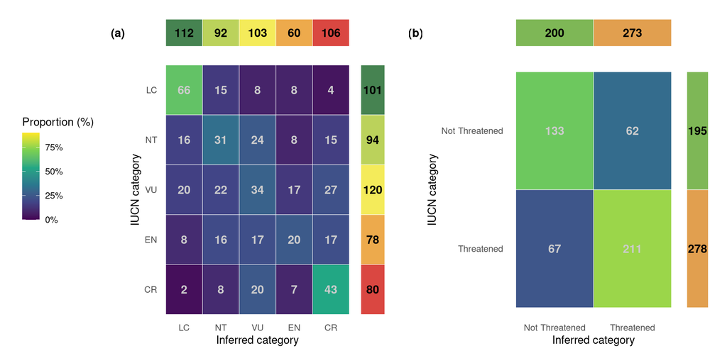

```r
cats_5 <- c("LC", "NT", "VU", "EN", "CR")
# table with four columns: evaluated label, predicted label, count, and proportion
conf_mat_5 <- data.frame(
  evaluated = factor(rep(cats_5, 5), levels = rev(cats_5)),
  predicted = factor(rep(cats_5, each = 5), levels = cats_5),
  count = c(model_5$confusion_matrix),
  prop = c(model_5$confusion_matrix / rowSums(model_5$confusion_matrix))
)
# table with two columns: name of the threat category, counts
conf_side_5 <- data.frame(
  evaluated = factor(cats_5, levels = rev(cats_5)),
  sum = rowSums(model_5$confusion_matrix)
)
conf_top_5 <- data.frame(
  predicted = factor(cats_5, levels = cats_5),
  sum = colSums(model_5$confusion_matrix)
)
# color codes for side and top bar
bar_keys_5 <- c("LC" = "#468351", "NT" = "#BBD25B", "VU" = "#F4EB5A",
                "EN" = "#EDAA4C", "CR" = "#DA4741")

cats_2 <- c("Not Threatened", "Threatened")
conf_mat_2 <- data.frame(
  evaluated = factor(rep(cats_2, 2), levels = rev(cats_2)),
  predicted = factor(rep(cats_2, each = 2), levels = cats_2),
  count = c(model_2$confusion_matrix),
  prop = c(model_2$confusion_matrix / rowSums(model_2$confusion_matrix))
)
conf_side_2 <- data.frame(
  evaluated = factor(cats_2, levels = rev(cats_2)),
  sum = rowSums(model_2$confusion_matrix)
)
conf_top_2 <- data.frame(
  predicted = factor(cats_2, levels = cats_2),
  sum = colSums(model_2$confusion_matrix)
)
bar_keys_2 <- c("Not Threatened" = "#7EB756", "Threatened" = "#E19F4F")

# Create ggplot elements
p_conf_mat_5 <- gg_confusion(conf_mat_5)
p_conf_side_5 <- gg_bar(conf_side_5, bar_keys_5)
p_conf_top_5 <- gg_bar(conf_top_5, bar_keys_5, side = FALSE)
p_tag_a <- gg_paneltag("(a)")

p_conf_mat_2 <- gg_confusion(conf_mat_2)
p_conf_side_2 <- gg_bar(conf_side_2, bar_keys_2)
p_conf_top_2 <- gg_bar(conf_top_2, bar_keys_2, side = FALSE)
p_tag_b <- gg_paneltag("(b)")

# Combine ggplot elements into a 3 columns x 2 rows layout
p_conf_5 <- wrap_plots(c(p_tag_a, p_conf_top_5, plot_spacer(),
                         plot_spacer(), p_conf_mat_5, p_conf_side_5)) +
  plot_layout(ncol = 3, nrow = 2,
              widths = c(0.3, 4, 0.6),
              heights = c(0.5, 4),
              guides = "collect") &
  theme(legend.position = "left")

p_conf_2 <- wrap_plots(c(p_tag_b, p_conf_top_2, plot_spacer(),
                         plot_spacer(), p_conf_mat_2, p_conf_side_2)) +
  plot_layout(ncol = 3, nrow = 2,
              widths = c(0.3, 4, 0.6),
              heights = c(0.5, 4),
              guides = "collect") &
  theme(legend.position = "none")

wrap_plots(patchworkGrob(p_conf_5), patchworkGrob(p_conf_2)) +
  plot_layout(ncol = 2, widths = c(1.1, 0.9))
```

**FIGURE S1** Confusion matrices showing the training performance of the best model for (a) 5-class and (b) 2-class predictions. The matrices should be read row-wise: rows represent the observed IUCN categories, whereas columns show the categories inferred by the models. The color gradient indicates the proportion relative to the observed number of species in each category. The side bar shows the observed number of species per category, and the top bar the total number inferred for each category. For example, of the 101 species classified as LC, 66 were correctly predicted as LC (65%), and the 5-class model overpredicted a total of 112 LC species.

### Predicted extinction risk of Hydrobiidae species

```r
pred_freq_5 <- table(pred_5$class_predictions)[c("LC", "NT", "VU", "EN", "CR")]
pred_freq_2 <- table(pred_2$class_predictions)
pred_freq_5
```

```
##
##  LC  NT  VU  EN  CR
##  62  32 106  40 163
```

```r
num_ass_threatened <- sum(iucn_labels_train$IUCN %in% c("VU", "EN", "CR"))
num_ass_threatened + sum(pred_freq_5[3:5])
```

```
## [1] 587
```

```r
pred_freq_2
```

```
##
## Not Threatened     Threatened
##             87            316
```

```r
num_ass_threatened + pred_freq_2[2]
```

```
## Threatened
##        594
```

We create a Sankey plot showing how Data Deficient (DD) and Not Evaluated (NE) species are assigned to the different threat categories. This requires three tables:

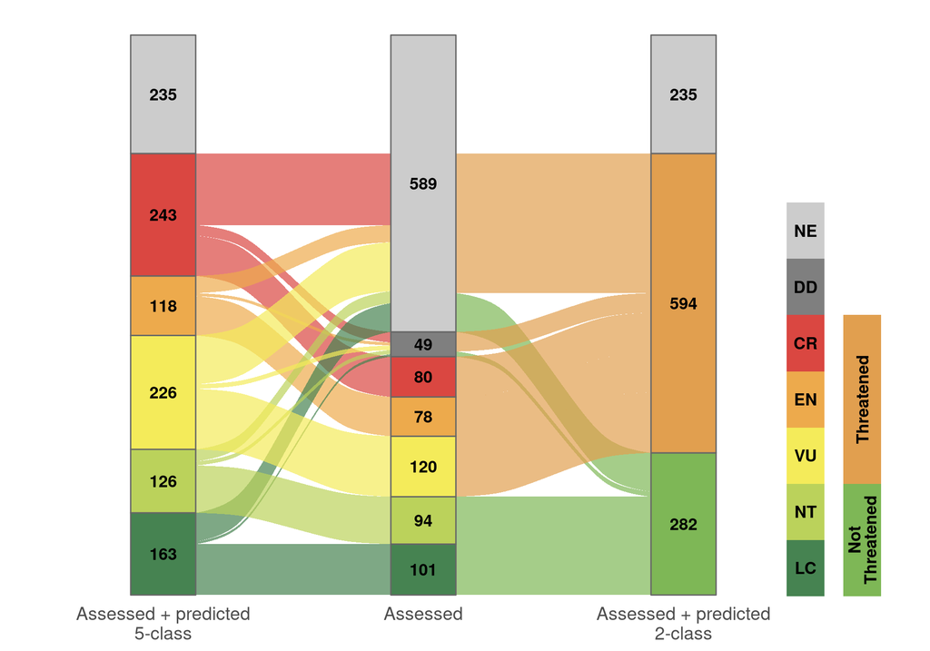

```r
# Assessed category frequencies
no_pred_NE <- 1111 - nrow(status)
ass_LC <- sum(status$IUCN == "LC")
ass_NT <- sum(status$IUCN == "NT")
ass_VU <- sum(status$IUCN == "VU")
ass_EN <- sum(status$IUCN == "EN")
ass_CR <- sum(status$IUCN == "CR")
ass_DD <- sum(status$IUCN == "DD")
ass_NE <- sum(status$IUCN == "NE") + no_pred_NE

# Assessed frequencies for each threat category
pred_LC_DD <- sum(status$class_5 == "LC" & status$IUCN == "DD")
pred_NT_DD <- sum(status$class_5 == "NT" & status$IUCN == "DD")
pred_VU_DD <- sum(status$class_5 == "VU" & status$IUCN == "DD")
pred_EN_DD <- sum(status$class_5 == "EN" & status$IUCN == "DD")
pred_CR_DD <- sum(status$class_5 == "CR" & status$IUCN == "DD")

# Predicted frequencies for the 2-class model
pred_LC_NE <- sum(status$class_5 == "LC" & status$IUCN == "NE")
pred_NT_NE <- sum(status$class_5 == "NT" & status$IUCN == "NE")
pred_VU_NE <- sum(status$class_5 == "VU" & status$IUCN == "NE")
pred_EN_NE <- sum(status$class_5 == "EN" & status$IUCN == "NE")
pred_CR_NE <- sum(status$class_5 == "CR" & status$IUCN == "NE")

# Predicted frequencies for the 5-class model
pred_N_DD <- sum(status$class_2 == "Not Threatened" & status$IUCN == "DD")
pred_T_DD <- sum(status$class_2 == "Threatened" & status$IUCN == "DD")
pred_N_NE <- sum(status$class_2 == "Not Threatened" & status$IUCN == "NE")
pred_T_NE <- sum(status$class_2 == "Threatened" & status$IUCN == "NE")

# Plot order
order_sankey <- c("L_NE", "L_CR" , "L_EN", "L_VU", "L_NT", "L_LC",
                  "C_NE", "C_DD", "C_CR", "C_EN", "C_VU", "C_NT", "C_LC",
                  "R_NE", "R_Threatened", "R_Not Threatened")

# Left, center, right vertical bar with category frequencies
# Left, center, right vertical bar with category frequencies
bars <- data.frame(
  stratum = factor(x = order_sankey, levels = order_sankey),
  species = c(
    # Not assessed and no prediction
    no_pred_NE,
    # Assessed + predicted CR
    ass_CR + pred_CR_DD + pred_CR_NE,
    # Assessed + predicted EN
    ass_EN + pred_EN_DD + pred_EN_NE,
    # Assessed + predicted VU
    ass_VU + pred_VU_DD + pred_VU_NE,
    # Assessed + predicted NT
    ass_NT + pred_NT_DD + pred_NT_NE,
    # Assessed + predicted LC
    ass_LC + pred_LC_DD + pred_LC_NE,
    # NE
    ass_NE,
    # Assessed DD
    ass_DD,
    # Assessed CR
    ass_CR,
    # Assessed EN
    ass_EN,
    # Assessed VU
    ass_VU,
    # Assessed NT
    ass_NT,
    # Assessed LC
    ass_LC,
    # Not assessed and no prediction
    no_pred_NE,
    # Assessed + predicted threatened
    ass_VU + ass_EN + ass_CR + pred_T_DD + pred_T_NE,
    # Assessed + predicted not threatened
    ass_LC + ass_NT + pred_N_DD + pred_N_NE
  ),
  stage = c(rep("Left", 6),
            rep("Center", 7),
            rep("Right", 3))
)

# Define how many species flow from the center to the left bar
# of the 2-class model
flow_right <- data.frame(
  alluvium = rep(1:16, each = 2),
  species = c(rep(ass_LC, 2), rep(ass_NT, 2),
              rep(ass_VU, 2), rep(ass_EN, 2), rep(ass_CR, 2),
              rep(pred_N_DD/2, 4),
              rep(pred_T_DD/3, 6),
              rep(pred_N_NE/2, 4),
              rep(pred_T_NE/3, 6),
              rep(no_pred_NE, 2)),
  Right_Color = c(rep("Right_Not_Threatened", 4),
                 rep("Right_Threatened", 6),
                 rep("Right_Not_Threatened", 4),
                 rep("Right_Threatened", 6),
                 rep("Right_Not_Threatened", 4),
                 rep("Right_Threatened", 6),
                 rep("Stay_Center", 2)),
  stage = rep(c("Right", "Center"), 16),
  stratum = factor(
    c("R_Not Threatened", "C_LC", "R_Not Threatened", "C_NT",
      "R_Threatened", "C_VU", "R_Threatened", "C_EN", "R_Threatened", "C_CR",
      "R_Not Threatened", "C_DD", "R_Not Threatened", "C_DD",
      "R_Threatened", "C_DD", "R_Threatened", "C_DD", "R_Threatened", "C_DD",
      "R_Not Threatened", "C_NE", "R_Not Threatened", "C_NE",
      "R_Threatened", "C_NE", "R_Threatened", "C_NE", "R_Threatened", "C_NE",
      "R_NE", "C_NE"),
    levels = order_sankey
  ),
  Flow_Color = c(rep("Right_Not_Threatened", 4),
                 rep("Right_Threatened", 6),
                 rep("Right_Not_Threatened", 4),
                 rep("Right_Threatened", 6),
                 rep("Right_Not_Threatened", 4),
                 rep("Right_Threatened", 6),
                 rep("Stay_Center", 2))
)

# Define how many species flow from the center to the left bar
# of the 2-class model
flow_left <- data.frame(
  alluvium = flow_right$alluvium,
  species = c(rep(ass_LC, 2), rep(ass_NT, 2),
              rep(ass_VU, 2), rep(ass_EN, 2), rep(ass_CR, 2),
              rep(pred_LC_DD, 2), rep(pred_NT_DD, 2),
              rep(pred_VU_DD, 2), rep(pred_EN_DD, 2), rep(pred_CR_DD, 2),
              rep(pred_LC_NE, 2), rep(pred_NT_NE, 2),
              rep(pred_VU_NE, 2), rep(pred_EN_NE, 2), rep(pred_CR_NE, 2),
              rep(no_pred_NE, 2)),
  Flow_Group = c(rep(rep(c("Left_LC", "Left_NT",
                           "Left_VU", "Left_EN", "Left_CR"), each = 2),
                     3),
                 rep("Stay_Center", 2)),
  stage = rep(c("Center", "Left"), 16),
  stratum = factor(
    c("C_LC", "L_LC", "C_NT", "L_NT", "C_VU", "L_VU",
      "C_EN", "L_EN", "C_CR", "L_CR", "C_DD", "L_LC",
      "C_DD", "L_NT", "C_DD", "L_VU", "C_DD", "L_EN",
      "C_DD", "L_CR", "C_NE", "L_LC", "C_NE", "L_NT",
      "C_NE", "L_VU", "C_NE", "L_EN", "C_NE", "L_CR",
      "C_NE", "L_NE"),
    levels = order_sankey
  ),
  Flow_Color = c(rep(rep(c("Left_LC", "Left_NT",
                           "Left_VU", "Left_EN", "Left_CR"), each = 2),
                     3),
                 rep("Stay_Center", 2))
)


# Sankey plot
font_size_categories <- 4.5
p_sankey <- ggplot() +
  # Left flows
  geom_flow(data = flow_left,
            aes(x = stage, y = species, stratum = stratum,
                alluvium = alluvium, fill = Flow_Color),
            alpha = 0.7, width = 1/4) +

  # Right flows
  geom_flow(data = flow_right,
            aes(x = stage, y = species, stratum = stratum,
                alluvium = alluvium, fill = Flow_Color),
            alpha = 0.7, width = 1/4) +

  # Bars
  geom_stratum(data = bars,
               aes(x = stage, y = species, stratum = stratum,
                   fill = stratum),
               width = 1/4, color = "grey40") +

  # Category labels
  geom_text(data = bars, stat = "stratum",
            aes(x = stage, y = species, stratum = stratum,
                label = species),
            fontface = "bold", size = font_size_categories) +

  # Bar names
  scale_x_discrete(
    limits = c("Left", "Center", "Right"),
    labels = c("Assessed + predicted\n5-class",
               "Assessed",
               "Assessed + predicted\n2-class")
  ) +

  # Flow colors
  scale_fill_manual(values = c(
    # Flow Colors
    "Right_Not_Threatened" = "#7EB756",
    "Right_Threatened"     = "#E19F4F",
    "Left_LC"              = "#468351",
    "Left_NT"              = "#BBD25B",
    "Left_VU"              = "#F4EB5A",
    "Left_EN"              = "#EDAA4C",
    "Left_CR"              = "#DA4741",
    "Stay_Center"          = "transparent",
    # Right Bar Colors
    "R_NE"                 = "grey80",
    "R_Threatened"         = "#E19F4F",
    "R_Not Threatened"     = "#7EB756",
    # Center Bar Colors
    "C_NE"                 = "grey80",
    "C_DD"                 = "grey50",
    "C_CR"                 = "#DA4741",
    "C_EN"                 = "#EDAA4C",
    "C_VU"                 = "#F4EB5A",
    "C_NT"                 = "#BBD25B",
    "C_LC"                 = "#468351",
    # Left Bar Colors
    "L_NE"                 = "grey80",
    "L_CR"                 = "#DA4741",
    "L_EN"                 = "#EDAA4C",
    "L_VU"                 = "#F4EB5A",
    "L_NT"                 = "#BBD25B",
    "L_LC"                 = "#468351"
  )) +
  # Scale y-stretching to minimize gap between bar labels and bars
  scale_y_continuous(expand = expansion(mult = c(0.01, 0.05))) +
  theme_minimal() +
  theme(
    legend.position = "none",
    panel.grid = element_blank(),
    axis.text.y = element_blank(),
    axis.title.y = element_blank(),
    axis.title.x = element_blank(),
    axis.text.x = element_text(size = 14, face = "plain"),
    plot.margin = margin(t = -40, r = -80, b = 0, l = -80, unit = "pt")
  )

# Legends for colors in Sankey plot
legend_5 <- data.frame(
  xmin  = 0.5,#2,
  xmax  = 1.5,#3,
  ymin  = 1:7,
  ymax  = 2:8,
  label = c("LC", "NT", "VU", "EN", "CR", "DD", "NE"),
  color = c("#468351", "#BBD25B", "#F4EB5A", "#EDAA4C",
            "#DA4741", "grey50", "grey80")
)

legend_2 <- data.frame(
  xmin  = 2,#0.5,
  xmax  = 3,#1.5,
  ymin  = c(1, 3),
  ymax  = c(3, 6),
  label = c("Not\nThreatened", "Threatened"),
  color = c("#7EB756", "#E19F4F")
)


p_legend_sankey <- ggplot() +
  # Legend 5-class
  geom_rect(data = legend_5,
            aes(xmin = xmin, xmax = xmax, ymin = ymin, ymax = ymax,
                fill = color)) +
  geom_text(data = legend_5,
            aes(x = (xmin + xmax)/2, y = (ymin + ymax)/2, label = label),
            size = font_size_categories, fontface = "bold", color = "black") +
  # Legend 2-class
  geom_rect(data = legend_2,
            aes(xmin = xmin, xmax = xmax, ymin = ymin, ymax = ymax,
                fill = color)) +
  geom_text(data = legend_2,
            aes(x = (xmin + xmax)/2, y = (ymin + ymax)/2, label = label),
            size = font_size_categories, fontface = "bold", color = "black",
            angle = 90, lineheight = 0.8) +
  # Interpret hex strings as colors
  scale_fill_identity() +
  # Axis limit Why setting to 2 to move it to the left???
  coord_cartesian(xlim = c(2, 4), ylim = c(1.4, 11), clip = "off") +
  theme_void() +
  theme(plot.margin = margin(t = 0, r = 0, b = 0, l = 0))

p_sankey + p_legend_sankey +
  plot_layout(ncol = 2, widths = c(1.0, 0.1), guides = "collect")
```

**FIGURE 2** Distribution of the number of species by threat status. Assessment of 876 hydrobiid species combining the IUCN Red List-assessed species (central column) and our predictions according to the 5-class model (left column) and 2-class model (right column).

### Feature importance and drivers of extinction risk

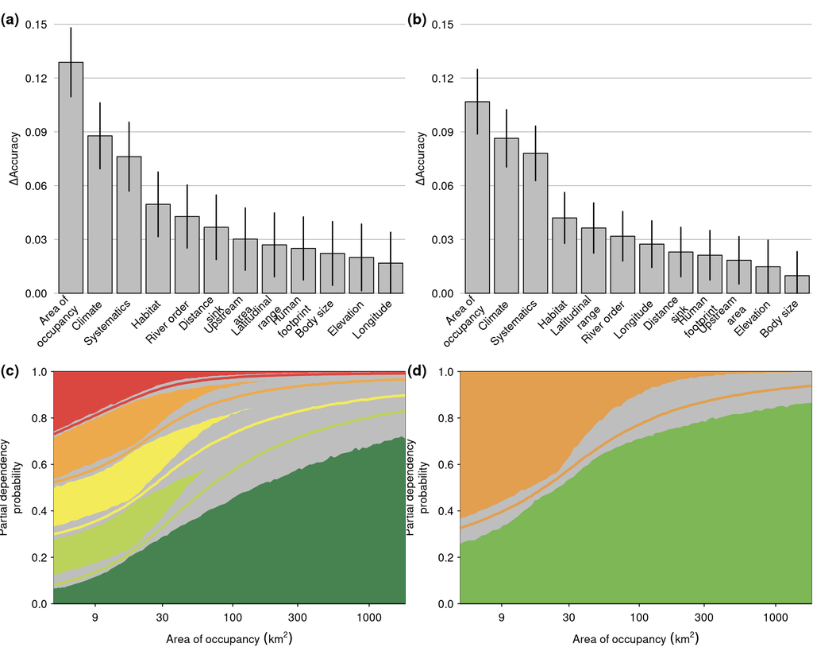

```r
layout(matrix(1:4, ncol = 2, nrow = 2, byrow = TRUE),
       heights = c(0.55, 0.45))

par(mgp = c(2.3, 0.5, 0), lheight = 0.7)
plot_iucnn_featimp(feat_imp_5, ylab = expression(paste(Delta, "Accuracy")),
                   ylim = c(0, 0.15), panel_tag = "(a)",
                   mar = c(4, 4, 1, 0.1))
plot_iucnn_featimp(feat_imp_2, ylab = expression(paste(Delta, "Accuracy")),
                   ylim = c(0, 0.15), panel_tag = "(b)",
                   mar = c(4, 4, 1, 0.1))



# AOO
ylab = "Partial dependency\nprobability"
mar <- c(3.5, 4, 1, 0.1)
par(mar = mar, tcl = -0.2)
plot(pdp_5, features = "aoo", xaxt = "n",
     xlab = expression("Area of occupancy"~(km^2)), ylab = ylab)
xaxt_label <- pretty(par('usr')[1:2])
xaxt_label <- signif(10**xaxt_label - 1, digits = 0)
xaxt <- log10(xaxt_label + 1)
axis(side = 1, at = xaxt, label = xaxt_label, xaxt = "s")
mtext("(c)", side = 3,
      line = -0.5, # up/down
      adj = -0.16, # left/right
      font = 2, cex = 1.1, las = 1)

par(mar = mar)
plot(pdp_2, features = "aoo", xaxt = "n" , col = c("#7EB756", "#E19F4F"),
     xlab = expression("Area of occupancy"~(km^2)), ylab = ylab)
xaxt_label <- pretty(par('usr')[1:2])
xaxt_label <- signif(10**xaxt_label - 1, digits = 0)
xaxt <- log10(xaxt_label + 1)
axis(side = 1, at = xaxt, label = xaxt_label, xaxt = "s")
par(xaxt = "s", yaxt = "s")
mtext("(d)", side = 3,
      line = -0.5,
      adj = -0.16,
      font = 2, cex = 1.1, las = 1)
```

**FIGURE 3** Importance and effects of predictors of extinction risk in Hydrobiidae. Predictor importance for the (a) 5-class and (b) 2-class models. Panels (c) and (d) show the marginal effects of area of occupancy (AOO) on the predicted probability of each threat category for the 5-class and 2-class models, respectively, while averaging over all remaining predictors. Colors correspond to IUCN threat categories

Here we create a supplementary plot of partial dependence probabilities for a few additional features.

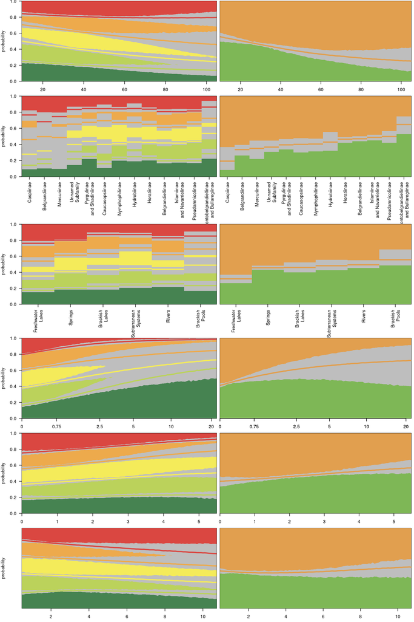

```r
# heights and margins around panels
n_rows <- 6
mar_left <- c(2.5, 4, 0.2, 0.5)
mar_right <- c(2.5, 0.1, 0.2, 0.5)
ylab = "Partial dependency\nprobability"

# 2 columns x 6 rows layout
layout(matrix(1:(2 * n_rows), ncol = 2, nrow = n_rows, byrow = TRUE),
       heights = c(0.1, 0.135, 0.12, 0.1, 0.1, 0.1),
       widths = c(0.53, 0.47))


# Hyclim15
par(mar = mar_left)
plot(pdp_5, features = "hyclim_15",
     xlab = "Precipitation seasonality (coefficient of variation)",
     ylab = ylab)
par(mar = mar_right)
plot(pdp_2, features = "hyclim_15", col = c("#7EB756", "#E19F4F"),
     xlab = "Precipitation seasonality (coefficient of variation)",
     ylab = "", yaxt = "n")
par(xaxt = "s", yaxt = "s")

# Systematic
par(mar = c(8.5, mar_left[2:4]))
plot(pdp_5, features = "systematics", order_categorical = FALSE, ylab = ylab)
par(mar = c(8.5, mar_right[2:4]))
plot(pdp_2, features = "systematics", col = c("#7EB756", "#E19F4F"),
     ylab = "", yaxt = "n")
par(xaxt = "s", yaxt = "s")

# Habitat
par(mar = c(6, mar_left[2:4]))
plot(pdp_5, features = "habitat", order_categorical = FALSE, ylab = ylab)
par(mar = c(6, mar_right[2:4]))
plot(pdp_2, features = "habitat", col = c("#7EB756", "#E19F4F"),
     ylab = "", yaxt = "n")
par(xaxt = "s", yaxt = "s")

# Latitudinal range
par(mar = mar_left)
plot(pdp_5, features = "lat_range", xaxt = "n",
     xlab = "Latitudinal range (°)", ylab = ylab)
xaxt_label <- c(0, 0.75, 2.5, 5, 10, 20)
xaxt <- log10(xaxt_label + 1)
axis(side = 1, at = xaxt, label = xaxt_label, xaxt = "s")
par(mar = mar_right)
plot(pdp_2, features = "lat_range", col = c("#7EB756", "#E19F4F"),
     xlab = "Latitudinal range (°)",
     ylab = "", yaxt = "n")
xaxt_label <- c(0, 0.75, 2.5, 5, 10, 20)
xaxt <- log10(xaxt_label + 1)
axis(side = 1, at = xaxt, label = xaxt_label, xaxt = "s")
xaxt_label <- c(0, 0.75, 2.5, 5, 10, 20)
xaxt <- log10(xaxt_label + 1)
axis(side = 1, at = xaxt, label = xaxt_label, xaxt = "s")
par(xaxt = "s", yaxt = "s")

# River order
par(mar = mar_left)
plot(pdp_5, features = "river_order",
     xlab = "Stream order (Strahler number)", ylab = ylab)
par(mar = mar_right)
plot(pdp_2, features = "river_order", col = c("#7EB756", "#E19F4F"),
     xlab = "Stream order (Strahler number)",
     ylab = "", yaxt = "n")

# Body size
par(mar = mar_left)
plot(pdp_5, features = "size",
     xlab = "Body size (mm)", ylab = ylab)
par(mar = mar_right)
plot(pdp_2, features = "size", col = c("#7EB756", "#E19F4F"),
     xlab = "Body size (mm)",
     ylab = "", yaxt = "n")
```

```r
par(xaxt = "s", yaxt = "s")
```

```r
# Reset graphic device
layout(matrix(1, 1, 1))
par(par_default)
```

### Variation in extinction risk

#### Habitat

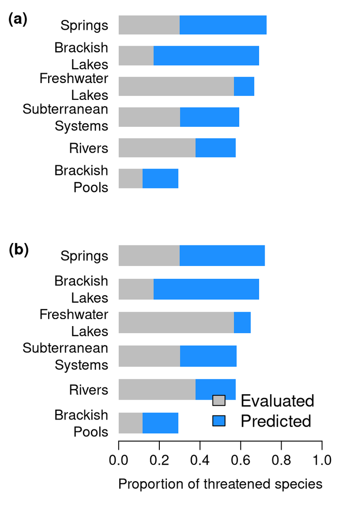

```r
habitat_freq <- data.frame(brackish_lakes = rep(0, 4),
                           brackish_pools = rep(0, 4),
                           freshwater_lakes = rep(0, 4),
                           rivers = rep(0, 4),
                           springs = rep(0, 4),
                           subterranean_systems = rep(0, 4),
                           row.names = c("assessed_2", "predicted_2",
                                         "assessed_5", "predicted_5"))

for (h in c("brackish_lakes", "brackish_pools", "freshwater_lakes",
            "rivers", "springs", "subterranean_systems")) {
  habitat_freq[1, h] <- sum(features[, h] == 1 &
                              status$assessed &
                              status$class_2 == "Threatened")
  habitat_freq[2, h] <- sum(features[, h] == 1 &
                              !status$assessed &
                              status$class_2 == "Threatened")
  habitat_freq[3, h] <- sum(features[, h] == 1 &
                              status$assessed &
                              status$class_5_binary == "Threatened")
  habitat_freq[4, h] <- sum(features[, h] == 1 &
                              !status$assessed &
                              status$class_5_binary == "Threatened")
  habitat_freq[, h] <- habitat_freq[, h] / sum(features[, h])
}

colnames(habitat_freq) <- c("Brackish\nLakes", "Brackish\nPools",
                            "Freshwater\nLakes", "Rivers",
                            "Springs", "Subterranean\nSystems")

par(las = 1, mar = c(2, 7, 0.5, 1), mgp = c(2, 0.6, 0))
layout(matrix(1:2, ncol = 1, nrow = 2), heights = c(0.45, 0.55))
ord <- order(colSums(habitat_freq[1:2, ]))
barplot(as.matrix(habitat_freq[1:2, ord]), xaxt = "n",
        col = c("grey", "dodgerblue"), border = NA, space = 0.6,
        xlab = "",
        beside = FALSE, horiz = TRUE, xlim = c(0, 1))
mtext("(a)", side = 3, line = -1.1, adj = -0.6, font = 2, cex = 1.1)

par(mar = c(4, 7, 0.5, 1))
ord <- order(colSums(habitat_freq[3:4, ]))
barplot(as.matrix(habitat_freq[3:4, ord]),
        col = c("grey", "dodgerblue"), border = NA, space = 0.6,
        xlab = "Proportion of threatened species",
        beside = FALSE, horiz = TRUE, xlim = c(0, 1))
mtext("(b)", side = 3, line = -1.2, adj = -0.6, font = 2, cex = 1.1)

legend("bottomright", legend = c("Evaluated", "Predicted"), bty = "n",
       fill = c("grey", "dodgerblue"), cex = 1.2)
```

```r
# Reset graphic device
layout(matrix(1, 1, 1))
par(par_default)
```

#### Geographic pattern

To display geographic patterns in both the observed and predicted datasets, we need to identify the freshwater `ecoregions` for each population `coords` and then to tally the species richness and number of threatened and proporton of threatened species per ecoregion. We add these stats to the attribute table of the `ecoregions` shapefile.

```r
# Add threat status to coordinates
m <- match(coords$species, status$species)
coords$assessed <- status$assessed[m]
coords$class_5 <- status$class_5_binary[m] == "Threatened"
coords$class_2 <- status$class_2[m] == "Threatened"

# Points to spatial object
coords_sf <- st_as_sf(coords[, 1:3],
                      coords = c("lon", "lat"),
                      crs = 4326)

# Get ecoregion ID for each coordinate (i.e. a population)
ecoregions_idx <- st_nearest_feature(coords_sf, ecoregions)
coords$FEOW_ID <- ecoregions$FEOW_ID[ecoregions_idx]

# Richness per ecoregion
richness <- table(unique(coords[, c("species", "FEOW_ID")])$FEOW_ID)
ecoregions$richness <- NA
m <- match(as.numeric(names(richness)), ecoregions$FEOW_ID)
ecoregions$richness[m] <- richness

# Number of assessed threatened species and their proportion per ecoregion
idx <- coords$assessed & coords$class_5
num_ass_threat <- table(unique(coords[idx, c("species", "FEOW_ID")])$FEOW_ID)
ecoregions$ass_threat <- NA
m <- match(as.numeric(names(num_ass_threat)), ecoregions$FEOW_ID)
ecoregions$ass_threat[m] <- num_ass_threat
rich_no_threat <- !is.na(ecoregions$richness) & is.na(ecoregions$ass_threat)
ecoregions$ass_threat[rich_no_threat] <- 0

# Number of assessed + predicted threatened species
# and their proportion per ecoregion
# 5-class model
idx <- coords$class_5
num_threat_5 <- table(unique(coords[idx, c("species", "FEOW_ID")])$FEOW_ID)
ecoregions$threat_5 <- NA
m <- match(as.numeric(names(num_threat_5)), ecoregions$FEOW_ID)
ecoregions$threat_5[m] <- num_threat_5
rich_no_threat <- !is.na(ecoregions$richness) & is.na(ecoregions$threat_5)
ecoregions$threat_5[rich_no_threat] <- 0
ecoregions$ratio_5 <- 100 * (ecoregions$threat_5 / ecoregions$richness)
# 2-class model
idx <- coords$class_2
num_threat_2 <- table(unique(coords[idx, c("species", "FEOW_ID")])$FEOW_ID)
ecoregions$threat_2 <- NA
m <- match(as.numeric(names(num_threat_2)), ecoregions$FEOW_ID)
ecoregions$threat_2[m] <- num_threat_2
rich_no_threat <- !is.na(ecoregions$richness) & is.na(ecoregions$threat_2)
ecoregions$threat_2[rich_no_threat] <- 0
ecoregions$ratio_2 <- 100 * (ecoregions$threat_2 / ecoregions$richness)

# Add Antarctica, which is missing from freshwater ecoregions
antarctica <- ne_countries(continent = "Antarctica",
                           returnclass = "sf")
antarctica <- st_sf(
  FEOW_ID = NA,
  AREA_SKM = NA,
  richness = NA,
  ass_threat = NA,
  threat_5 = NA,
  ratio_5 = NA,
  threat_2 = NA,
  ratio_2 = NA,
  geometry = st_geometry(antarctica),
  crs = st_crs(antarctica)
)
antarctica <- antarctica[, colnames(ecoregions)]
ecoregions_combined <- rbind(ecoregions, antarctica)
```

Now we can plot the distribution of threatened diversity.

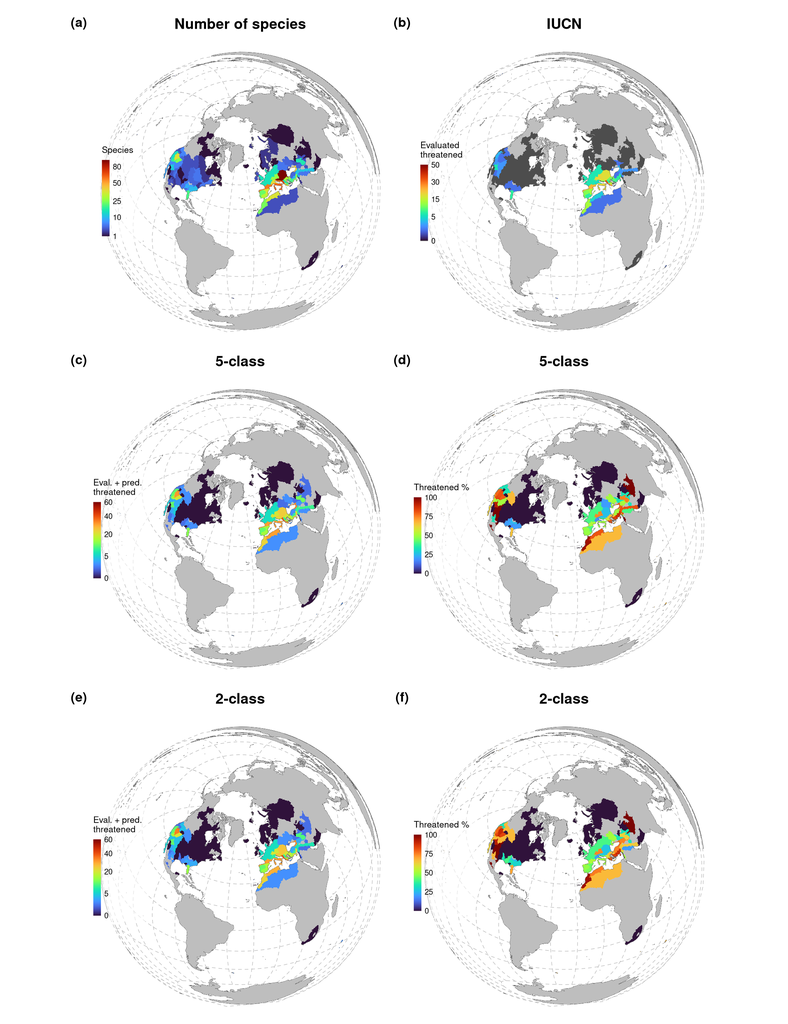

```r
# Avoid corrupting polygons when changing coordinate reference system
ecoregions_fixed <- suppressWarnings(
  suppressMessages(
    st_break_antimeridian(ecoregions_combined, lon_0 = -30)
  )
)

# Change ecoregion coordinate reference system to Winkle Triple
plot_crs <- "+proj=laea +lat_0=44 +lon_0=-30
                        +x_0=0 +y_0=0
                        +ellps=GRS80 +units=m +no_defs"


# Set ggplot theme for all maps
map_theme <- theme(
  # Hide box
  panel.border = element_blank(),
  # Hide axis text (coordinates)
  axis.text = element_blank(),
  # Hide axis ticks
  axis.ticks = element_blank(),
  # Enable and style the graticule lines
  panel.grid.major = element_line(color = "gray70",
                                  linetype = "dashed",
                                  linewidth = 0.2),
  panel.grid.minor = element_blank(),
  # Transparent background
  plot.background = element_blank(),
  panel.background = element_blank(),
  # legend.background = element_blank(),
  # Legend position
  legend.position = c(0.1, 0.5),     # Adjust x and y
  legend.justification = c(0.5, 0.5), # Center anchor point of the legend box
  legend.direction = "vertical",
  legend.background = element_rect(fill = alpha("white", 0.6), color = NA),
  legend.key.width = unit(7, "pt"),
  legend.key.height = unit(14, "pt"),
  legend.title = element_text(size = 8),
  legend.text = element_text(size = 7),
  # No margin around maps
  plot.margin = margin(0.0, 0.0, 0, 0.0, "in"),
  # Centered bold-faced title
  plot.title = element_text(hjust = 0.5, face = "bold"),
)

# Bring numbers closer to legend
guide <- guide_colorbar(
  label.theme = element_text(margin = margin(l = 3, r = 0, unit = "pt")),
  ticks.linewidth = unit(0.0, "pt"),
  nbin = 300
)

# Richness map
map_richness <- ggplot(data = ecoregions_fixed) +
  geom_sf() +
  geom_sf(aes(fill = richness),
          linewidth = 0.05, col = NA) +
  scale_fill_gradientn(
    colors = viridis::turbo(100),
    trans = "sqrt",  # Apply sqrt transformation
    limits = c(1, NA),
    breaks = c(1, 10, 25, 50, 80),  # Set breaks starting at 1
    labels = c("1", "10", "25", "50", "80"),  # Customize labels
    na.value = "grey",  # Color for regions without Hydrobiidae
    name = "Species",
    guide = guide
  ) +
  coord_sf(crs = plot_crs) +
  scale_x_continuous(breaks = seq(-180, 180, by = 20)) +
  scale_y_continuous(breaks = seq(-90, 90, by = 20)) +
  map_theme +
  labs(title = "Number of species")

# Map of assessed and threatened species
map_ass_threat <- ggplot(data = ecoregions_fixed) +
  geom_sf() +
  geom_sf(aes(fill = ass_threat),
          linewidth = 0.05, col = NA) +
  scale_fill_gradientn(
    colors = c("grey30", viridis::turbo(99)),
    trans = "sqrt",  # Apply sqrt transformation
    limits = c(0, 50),
    breaks = c(0, 5, 15, 30, 50),  # Set breaks starting at 1
    labels = c("0", "5", "15", "30", "50"),  # Customize labels
    na.value = "grey",  # Color for regions without Hydrobiidae
    name = "Evaluated\nthreatened",
    guide = guide
  ) +
  coord_sf(crs = plot_crs) +
  scale_x_continuous(breaks = seq(-180, 180, by = 20)) +
  scale_y_continuous(breaks = seq(-90, 90, by = 20)) +
  map_theme +
  labs(title = "IUCN")

# Map of assessed + predicted threatened species according to 5-class model
map_threat_5 <- ggplot(data = ecoregions_fixed) +
  geom_sf() +
  geom_sf(aes(fill = threat_5),
          linewidth = 0.05, col = NA) +
  scale_fill_gradientn(
    colors = viridis::turbo(100),
    trans = "sqrt",  # Apply sqrt transformation
    limits = c(0, 60),
    breaks = c(0, 5, 20, 40, 60),  # Set breaks starting at 0
    labels = c("0", "5", "20", "40", "60"),  # Customize labels
    na.value = "grey",  # Color for regions without Hydrobiidae
    name = "Eval. + pred.\nthreatened",
    guide = guide
  ) +
  coord_sf(crs = plot_crs) +
  scale_x_continuous(breaks = seq(-180, 180, by = 20)) +
  scale_y_continuous(breaks = seq(-90, 90, by = 20)) +
  map_theme +
  labs(title = "5-class")

# Proportion of assessed + predicted threatened species according to 5-class model
map_ratio_5 <- ggplot(data = ecoregions_fixed) +
  geom_sf() +
  geom_sf(aes(fill = ratio_5),
          linewidth = 0.05, col = NA) +
  scale_fill_gradientn(
    colors = viridis::turbo(100),
    limits = c(0, 100),
    na.value = "grey",  # Color for regions without Hydrobiidae
    name = "Threatened %",
    guide = guide
  ) +
  coord_sf(crs = plot_crs) +
  scale_x_continuous(breaks = seq(-180, 180, by = 20)) +
  scale_y_continuous(breaks = seq(-90, 90, by = 20)) +
  map_theme +
  labs(title = "5-class")

# Map of assessed + predicted threatened species according to 2-class model
map_threat_2 <- ggplot(data = ecoregions_fixed) +
  geom_sf() +
  geom_sf(aes(fill = threat_2),
          linewidth = 0.05, col = NA) +
  scale_fill_gradientn(
    colors = viridis::turbo(100),
    trans = "sqrt",  # Apply sqrt transformation
    limits = c(0, 60),
    breaks = c(0, 5, 20, 40, 60),  # Set breaks starting at 0
    labels = c("0", "5", "20", "40", "60"),  # Customize labels
    na.value = "grey",  # Color for regions without Hydrobiidae
    name = "Eval. + pred.\nthreatened",
    guide = guide
  ) +
  coord_sf(crs = plot_crs) +
  scale_x_continuous(breaks = seq(-180, 180, by = 20)) +
  scale_y_continuous(breaks = seq(-90, 90, by = 20)) +
  map_theme +
  labs(title = "2-class")

# Proportion of assessed + predicted threatened species according to 5-class model
map_ratio_2 <- ggplot(data = ecoregions_fixed) +
  geom_sf() +
  geom_sf(aes(fill = ratio_2),
          linewidth = 0.05, col = NA) +
  scale_fill_gradientn(
    colors = viridis::turbo(100),
    limits = c(0, 100),
    na.value = "grey",  # Color for regions without Hydrobiidae
    name = "Threatened %",
    guide = guide
  ) +
  coord_sf(crs = plot_crs) +
  scale_x_continuous(breaks = seq(-180, 180, by = 20)) +
  scale_y_continuous(breaks = seq(-90, 90, by = 20)) +
  map_theme +
  labs(title = "2-class")

# Combine into 2 x 3 layout
combined_maps <- map_richness + map_ass_threat +
  map_threat_5 + map_ratio_5 +
  map_threat_2 + map_ratio_2 +
  plot_layout(ncol = 2, nrow = 3) +
  plot_annotation(tag_levels = "a", tag_prefix = "(", tag_suffix = ")")

# Force (a), (b), etc to be bold face
combined_maps <- combined_maps & theme(
  plot.tag = element_text(face = "bold", size = 12, vjust = -3))

# Plot all maps together
combined_maps
```

#### Phylogenetic pattern

One panel displays a circular plot of a taxonomically augmented phylogeny comprising all 876 species. Branches are color-coded according to Brownian motion estimates of ancestral evolutionary distinctiveness. Lines at the tips indicate the observed or inferred IUCN category. Arcs denote subfamilies.

A second panel shows the proportion of threatened evolutionary history of Hydrobiidae and selected animal and plant groups.

```r
# Remove quotes around species names put there by dendropy, which is a
# dependency of TACT to augment the tree
tree$tip.label <- gsub("'", "", tree$tip.label)

# Order tree according to branch lengths for nicer plot
tree <- ladderize(tree)

# ED algorithm of Isaac et al. (2007)
ed <- evol.distinct(tree, type = "fair.proportion")

# Order alphabetically as in the assessed and predicted threat status
ed <- ed[order(ed$Species), ]

# log10 transformation for Brownian motion estimation
ed_log <- log10(ed[, 2])
names(ed_log) <- ed[, 1]

# Ancestral state estimation of evolutionary distinctiveness
# We do not want the default plot, but we need the coordinates for all branches
# to make a custom plot showing the extinction threat at the tips.
# We dump the plot into an empty PDF to get the coordinates
root_age <- max(nodeHeights(tree))
mar_tree <- 0.03 # margins around circular tree plot
xy_lim <- root_age + root_age * mar_tree

pdf(file = NULL)
ed_ace <- contMap(tree, x = ed_log, type = "fan",
                  plot = TRUE, fsize = c(0.001, 1),
                  xlim = c(-xy_lim, xy_lim),
                  ylim = c(-xy_lim, xy_lim))
dev.off()
```

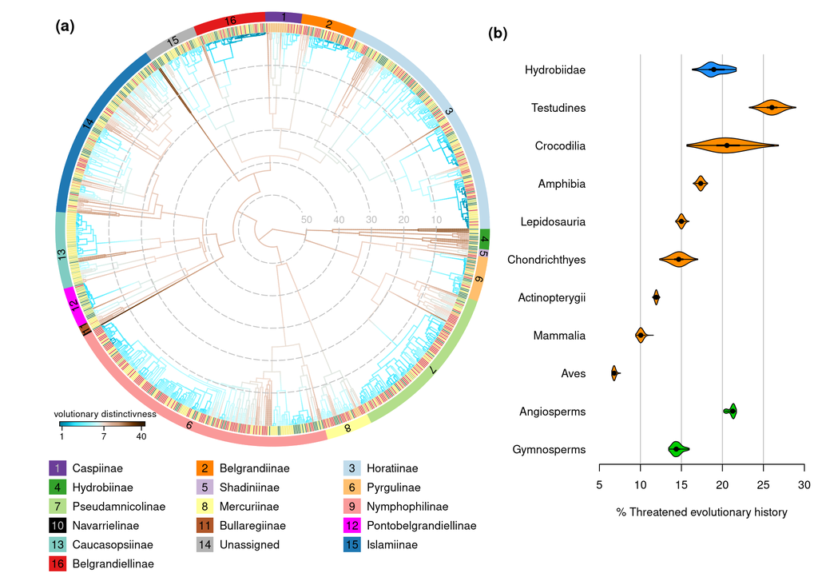

```r
# Get tip coordinates
n_species <- Ntip(tree)
tip_coords <- get("last_plot.phylo", envir = .PlotPhyloEnv)
tip_x <- tip_coords$xx[1:n_species]
tip_y <- tip_coords$yy[1:n_species]

# Calculate the radius for each tip
current_radius <- sqrt(tip_x^2 + tip_y^2)

# Normalize the direction (unit vector) for each tip
direction_x <- tip_x / current_radius
direction_y <- tip_y / current_radius

# Increase the radius by a the length of the lines
# for the threat status and subfamilies
radius_origin_threat <- current_radius + 0.2
radius_endpoint_threat <- current_radius + 3
radius_origin_subfam <- current_radius + 3.5
radius_endpoint_subfam <- current_radius + 6.5

# Calculate new x and y coordinates for the threat status and subfamilies
x_origin_threat <- direction_x * radius_origin_threat
y_origin_threat <- direction_y * radius_origin_threat
x_endpoint_threat <- direction_x * radius_endpoint_threat
y_endpoint_threat <- direction_y * radius_endpoint_threat
x_origin_subfam <- direction_x * radius_origin_subfam
y_origin_subfam <- direction_y * radius_origin_subfam
x_endpoint_subfam <- direction_x * radius_endpoint_subfam
y_endpoint_subfam <- direction_y * radius_endpoint_subfam


# Set the colors for the IUCN categories at the tips
m <- match(ed_ace$tree$tip.label, status$species)
iucn_cats <- factor(status$class_5[m],
                    levels = c("LC", "NT", "VU", "EN", "CR"))
col_tip_threat <- c("#468351", "#BBD25B", "#F4EB5A",
                    "#EDAA4C", "#DA4741")[iucn_cats]

# Set the colors for the subfamilies at the tips
systematic$species <- gsub(" ", "", systematic$species) # Remove spaces
m <- match(ed_ace$tree$tip.label, systematic$species)
col_tip_subfam <- rep(rgb(70, 70, 70, maxColorValue = 100), n_species)
col_subfam <- data.frame(
  subfamily = c("Caspiinae",
                "Belgrandiinae",
                "Horatiinae",
                "Hydrobiinae",
                "Shadiniinae",
                "Pyrgulinae",
                "Pseudamnicolinae",
                "Mercuriinae",
                "Nymphophilinae",
                "Navarrielinae",
                "Bullaregiinae",
                "Pontobelgrandiellinae",
                "Caucasopsiinae",
                "Islamiinae",
                "Belgrandiellinae"),
  col = c(rgb(42, 24, 60, maxColorValue = 100),
          rgb(100, 50, 0, maxColorValue = 100),
          rgb(75, 86, 92, maxColorValue = 100),
          rgb(20, 63, 17, maxColorValue = 100),
          rgb(79, 70, 84, maxColorValue = 100),
          rgb(100, 75, 43, maxColorValue = 100),
          rgb(70, 87, 54, maxColorValue = 100),
          rgb(100, 100, 60, maxColorValue = 100),
          rgb(98, 60, 60, maxColorValue = 100),
          rgb(0, 0, 0, maxColorValue = 100),
          rgb(69, 34, 16, maxColorValue = 100),
          rgb(100, 0, 100, maxColorValue = 100),
          rgb(50, 80, 76, maxColorValue = 100),
          rgb(12, 47, 70, maxColorValue = 100),
          rgb(89, 10, 11, maxColorValue = 100))
)

for(i in 1:nrow(col_subfam)) {
  idx <- systematic$subfamily[m] == col_subfam[i, 1]
  col_tip_subfam[idx] <- col_subfam[i, 2]
}

# Set colors for the ED gradient along branches
ed_cols <- rev(c("#331A00FF", "#663000FF", "#996136FF", "#CC9B7AFF",
                 "#D9AF98FF", "#F2DACEFF", "#CCFDFFFF", "#99F8FFFF",
                 "#66F0FFFF", "#33E4FFFF", "#00AACCFF", "#007A99FF"))
ed_ace <- setMap(ed_ace, colors = ed_cols)


# Combine threatened history from literature with Hydrobiidae estimates
threatened_pd_combined <- rbind(
  threatened_pd,
  data.frame(clade = "Hydrobiidae",
             perc.ePDloss = 100 * ePD_loss$ePDloss_prop))

# Set clade names and colors for violin plot
clades <- c("Gymnosperms", "Angiosperms", "Aves", "Mammalia",
            "Actinopterygii", "Chondrichthyes", "Lepidosauria",
            "Amphibia", "Crocodilia", "Testudines", "Hydrobiidae")
clade_col <- c(rep("green3", 2), rep("darkorange", 8), "dodgerblue")


layout(matrix(c(1, 2, 3, 3), ncol = 2, nrow = 2),
       widths = c(0.6, 0.4), heights = c(0.8, 0.2))

# Plot tree with ED gradient
plot(ed_ace, lwd = 1.2, type = "fan", ftype = "off",
     outline = FALSE, legend = FALSE, mar = c(0, 4, 0, 0),
     xlim = c(-xy_lim, xy_lim),
     ylim = c(-xy_lim, xy_lim))


# Add circles indicating age
ages <- c(10, 20, 30, 40, 50)
end_rad <- c(-354, -353, -350, -345, -330)
for (i in 1:length(ages)) {
  # Arc from 2 to end_rad  degrees in radians
  theta <- seq(1 * (pi / 180), end_rad[i] * (pi / 180), length.out = 100)
  age <- ages[i]
  lines(x = 0 + (root_age - age) * cos(theta),
        y = 0 + (root_age - age) * sin(theta),
        col = "grey", lty = 5)
  text(x = root_age - age, y = 3, labels = age, col = "grey", cex = 0.9)
}


# Make a legend where the log10 ED values are transformed to natural scale
x_bar <- -65 # left margin of the color.bar
y_bar <- -60

bar_ticks <- c(ed_ace$lims[1], sum(ed_ace$lims)/2, ed_ace$lims[2])
bar_ticks_pretty <- signif(10**bar_ticks, digits = 1)
bar_at <- x_bar +
  25 * (log10(bar_ticks_pretty) - min(bar_ticks)) / max(bar_ticks)
for (i in 1:length(bar_at)) {
  lines(rep(bar_at[i], 2), c(y_bar, y_bar - 2))
  text(x = bar_at[i], y = y_bar - 1, labels = bar_ticks_pretty[i],
       pos = 1, cex = 0.8)
}

add.color.bar(leg = 25, ed_ace$cols,
              prompt = FALSE, x = x_bar, y = y_bar,
              title = "Evolutionary distinctivness", fsize = 0.8,
              subtitle = "", lims=NULL)


# Add lines for threat status
segments(x_origin_threat, y_origin_threat,
         x_endpoint_threat, y_endpoint_threat,
         col = col_tip_threat, lwd = 1, lend = 3)

# Add subfamilies
segments(x_origin_subfam, y_origin_subfam,
         x_endpoint_subfam, y_endpoint_subfam,
         col = col_tip_subfam, lwd = 3, lend = 3)

# Add numbers to colored arcs
tip_angles_rad <- atan2(direction_y, direction_x)
for (i in 1:nrow(col_subfam)) {
  if (i == 10) {
    add_to_plot <- FALSE
  }
  else if (i == 13) {
    middle <- -3.02
    add_to_plot <- TRUE
    label <- as.character(i)
  }
  else if (i == 15) {
    idx <- systematic$subfamily[m] == col_subfam[i, 1]
    middle <- mean(tip_angles_rad[idx])
    add_to_plot <- TRUE
    label <- as.character(i + 1)
  }
  else {
    idx <- systematic$subfamily[m] == col_subfam[i, 1]
    middle <- mean(tip_angles_rad[idx])
    add_to_plot <- TRUE
    label <- as.character(i)
  }
  if (add_to_plot) {
    arctext(x = label, cex = 0.8,
            center = c(0, 0), radius = radius_origin_subfam[1] * 1.025,
            middle = middle)
  }
}
arctext(x = "15", cex = 0.8,
        center = c(0, 0), radius = radius_origin_subfam[1] * 1.025,
        middle = 2.06)

text(x = -64, y = xy_lim * 1.0, labels = "(a)", font = 2, cex = 1.4)

# Subfamily legend
par(mar = rep(0, 4))
plot(1, 1, xlim = c(-2, 18), ylim = c(6, 0), xaxs = "i", yaxs = "i",
     type = "n", axes = FALSE, xlab = "", ylab = "")
ybottom <- c(rep(0, 3), rep(1, 3), rep(2, 3), rep(3, 3), rep(4, 3), 5) + 0.1
ytop <- ybottom + 0.8
xleft <- c(rep(c(0, 6, 12), 5), 0)
xright <- xleft + 0.7
font_size <- 1

for (i in 1:16) {
  col_number <- "black"
  if (i %in% c(1, 10)) {
    col_number <- "grey"
  }
  if (i < 14) {
    col <- col_subfam[i, 2]
    label <- col_subfam[i, 1]
  }
  else if (i == 14) {
    col <- rgb(70, 70, 70, maxColorValue = 100)
    label <- "Unassigned"
  }
  else {
    col <- col_subfam[i - 1, 2]
    label <- col_subfam[i - 1, 1]
  }
  rect(xleft[i], ybottom[i], xright[i], ytop[i],
       col = col, border = NA)
  x <- (xleft[i] + xright[i]) / 2
  y <- (ybottom[i] + ytop[i]) / 2
  text(x, y, labels = as.character(i), adj = c(0.5, 0.5),
       cex = font_size, col = col_number)
  text(x + 0.6, y, labels = label, adj = c(0, 0.5), cex = font_size)
}

# Threatened evolutionary history
par(las = 1, mar = c(8, 8, 4, 1))
plot(1, 1, type = "n", ylim = c(1, 11), xlim = c(5, 30), xaxs = "i",
     xlab = "% Threatened evolutionary history", ylab = "",
     axes = FALSE)
abline(v = seq(10, 25, 5), col = "grey")
axis(side = 1, at = seq(0, 30, 5))
axis(side = 2, at = 1:11, lwd = 0, labels = clades)
for (i in 1:length(clades)) {
  vioplot(threatened_pd_combined$perc.ePDloss[
          threatened_pd_combined$clade == clades[i]],
          at = i, wex = 0.5, horizontal = TRUE,
          col = clade_col[i], colMed = "black",
          axes = FALSE, add = TRUE)
}

mtext("(b)", side = 3,
      line = 1.0,  # up/down
      adj = -0.6, # left/right
      font = 2, cex = 1.1, las = 1)
```

**FIGURE 5** Evolutionary distinctiveness (ED), extinction risk, and threatened evolutionary history in Hydrobiidae. (a) Augmented phylogeny of Hydrobiidae with branches colored according to ED values. Tip colors represent IUCN Red List categories, including both evaluated and model-predicted (5-class) classifications. Numbers at the dashed circles indicate the ages of speciation events in millions of years. (b) Estimated proportion of threatened evolutionary history in Hydrobiidae relative to other major taxonomic groups (data from [Grumbs et al. 2023](https://journals.plos.org/plosbiology/article?id=10.1371/journal.pbio.3001991); [Forest et al. 2026](https://www.science.org/doi/10.1126/science.adz0773))

```r
# Reset graphic device
layout(matrix(1, 1, 1))
par(par_default)
```

#### EDGE distribution

The last plot shows the distribution of EDGE scores across phylogenetic and extinction risk uncertainty for the 50 most evolutionary distinct and endangered species.

```r
# EDGE score summaries per species
edge_score_stats <- aggregate(edge ~ species,
                              data = edge_scores,
                              FUN = median)
colnames(edge_score_stats)[2] <- "EDGE_median"
edge_score_stats$EDGE_mean <- aggregate(edge ~ species,
                                        data = edge_scores,
                                        FUN = mean)[, 2]
edge_score_stats$EDGE_sd <- aggregate(edge ~ species,
                                      data = edge_scores,
                                      FUN = sd)[, 2]
edge_score_stats$ED_median <- aggregate(ed ~ species,
                                        data = edge_scores,
                                        FUN = median)[, 2]
edge_score_stats$ED_mean <- aggregate(ed ~ species,
                                      data = edge_scores,
                                      FUN = mean)[, 2]
edge_score_stats$ED_sd <- aggregate(ed ~ species,
                                    data = edge_scores,
                                    FUN = sd)[, 2]
```

Next, we identify the EDGE species.

```r
# Times EDGE scores of a species exceeds the median
n_exceed <- colSums(edge_exceed)

# Species has above median EDGE across 95% of iterations
is_edge_species <- n_exceed > 0.95 * pred_dropout_reps

# Species listed as threatened on Red List need to exceed median
# only across 80% of iterations (Gumbs et al. 2023 Fig. 2)
threat_eval_species <- iucn_labels$IUCN %in% c("VU", "EN", "CR")
is_edge_species[threat_eval_species] <-
  n_exceed[threat_eval_species] > 0.8 * pred_dropout_reps
```

```r
mean(ePD_loss$ePDloss)
```

```
## [1] 769.8377
```

```r
mean(ePD_loss$ePDloss_prop)
```

```
## [1] 0.1921719
```

```r
sum(is_edge_species)
```

```
## [1] 182
```

```r
max(edge_score_stats$EDGE_mean[is_edge_species])
```

```
## [1] 10.87785
```

```r
mean(edge_score_stats$EDGE_mean[is_edge_species])
```

```
## [1] 2.858071
```

Joyplot of the EDGE score distributions for the top 50 species.

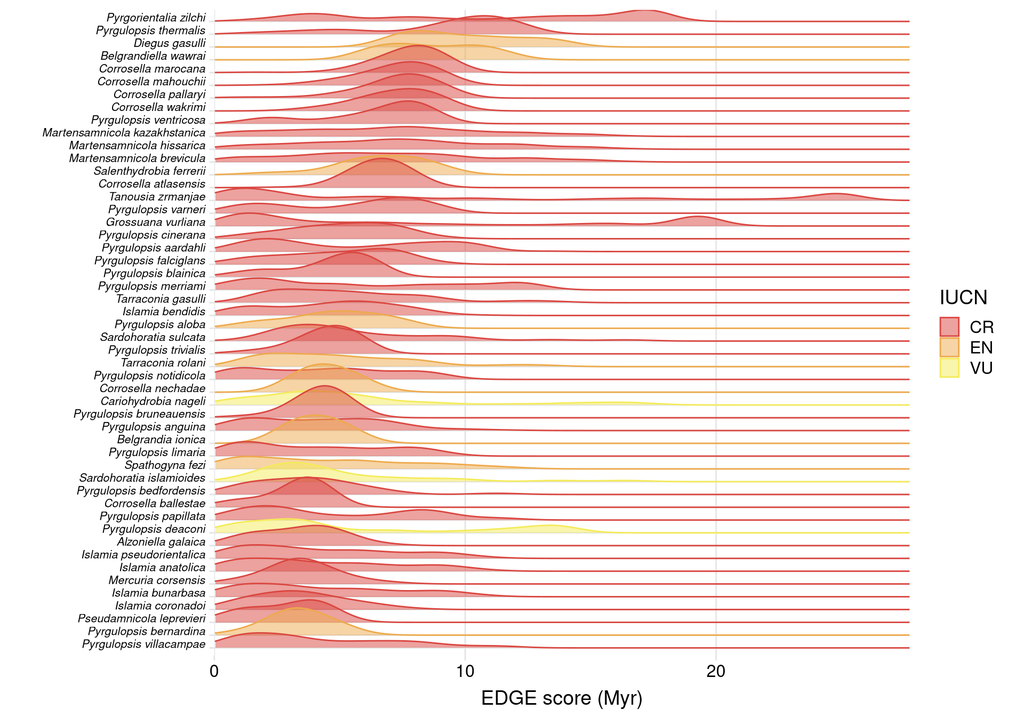

```r
# Just EDGE species
edge_species_stats <- edge_score_stats[is_edge_species, ]

# Order EDGE score decreasingly
edge_species_stats <- edge_species_stats[
  order(edge_species_stats$EDGE_median, decreasing = TRUE), ]

# Subset edge_score by the top 50 species
top_50_species <- rev(edge_species_stats$species[1:50])
top_50_edge_scores <- edge_scores[edge_scores$species %in% top_50_species, ]

# omit _ between genus and species for nicer plot labels
top_50_species <- gsub("_", " ", top_50_species)
top_50_edge_scores$species <- gsub("_", " ", top_50_edge_scores$species)

# Set ordered species as factor to order plot descendingly
top_50_edge_scores$species <- factor(top_50_edge_scores$species,
                                     levels = top_50_species)

# Set IUCN colors
iucn_cols <- c("LC" = "#468351", "NT" = "#BBD25B", "VU" = "#F4EB5A",
               "EN" = "#EDAA4C", "CR" = "#DA4741")

# Make joyplot
ggplot(top_50_edge_scores,
       aes(x = edge, y = species, fill = IUCN, color = IUCN)) +
  geom_density_ridges(alpha = 0.5,
                      scale = 2.5) +
  scale_x_continuous(limits = c(0, NA), expand = c(0, 0)) +
  scale_fill_manual(values = iucn_cols) +
  scale_color_manual(values = iucn_cols) +
  theme_ridges() +
  labs(x = "EDGE score (Myr)", y = "") +
  theme(legend.position = "right",
        axis.title.x = element_text(hjust = 0.5, margin = margin(t = 5)),
        axis.text.y = element_text(face = "italic", size = 8))
```

**FIGURE S3** Distribution of EDGE scores for the 50 top-ranked Hydrobiidae species. Ridgelines represent the variation in EDGE values across phylogenetic replicates, with colors indicating IUCN threat categories. Species with the highest scores represent disproportionate amounts of threatened evolutionary history and therefore constitute priorities for conservation. EDGE scores and the probabilities of qualifying as EDGE species for the remaining species are provided in Table S4.

#### Summarizing extinction risk in supplementary tables

Lastly, we create Supplementary Tables S4 and S5. Table S4 contains the assessed and inferred IUCN categories, their prediction uncertainty, and EDGE scores for all 876 species, whereas Table S5 summarizes the distribution of threatened evolutionary history and its proportion in realtion to the root age.

```r
# Give a probability of 1 for the categories of assessed spesies
ass_prob <- model.matrix(species ~ IUCN - 1, iucn_labels[train_idx, ])
ass_prob_5 <- ass_prob[, c("IUCNLC", "IUCNNT", "IUCNVU", "IUCNEN", "IUCNCR")]
ass_prob_2 <- cbind(as.numeric(rowSums(ass_prob_5[, 1:2]) > 0),
                    as.numeric(rowSums(ass_prob_5[, 3:5]) > 0))

# Combine assessed species with dropout probs for predicted species
pred_prob_5 <- rbind(ass_prob_5, pred_5$mc_dropout_probs)
pred_prob_2 <- rbind(ass_prob_2, pred_2$mc_dropout_probs)

# Set rownames
rownames(pred_prob_5) <- c(iucn_labels$species[train_idx],
                           pred_5$names)
rownames(pred_prob_2) <- c(iucn_labels$species[train_idx],
                           pred_2$names)

# Order alphabetically
pred_prob_5 <- pred_prob_5[order(rownames(pred_prob_5)), ]
pred_prob_2 <- pred_prob_2[order(rownames(pred_prob_2)), ]

# Set colnames
colnames(pred_prob_5) <- c("prob_LC", "prob_NT", "prob_VU",
                           "prob_EN", "prob_CR")
colnames(pred_prob_2) <- c("prob_Not_Threatened", "prob_Threatened")


iucnn_summary <- data.frame(status[, -6], pred_prob_5, pred_prob_2,
                            edge_score_stats[, -1],
                            EDGE_species = is_edge_species,
                            EDGE_prob =  n_exceed / pred_dropout_reps,
                            row.names = NULL)

# Commented out for not overwritting original output
# write.table(iucnn_summary,
#             file.path("..", "Table_S4.txt"),
#             row.names = FALSE, quote = FALSE, sep = "\t")

# write.table(ePD_loss,
#             file.path("..", "Table_S5.txt"),
#             row.names = FALSE, quote = FALSE, sep = "\t")
```

#### Package and versions

The python packages were used:

```r
reticulate::py_run_string(
"
import pkg_resources
import sys

print('Python version:', sys.version)

for pkg in pkg_resources.working_set:
    print(f'{pkg.key}=={pkg.version}')
"
)
```

```
## Python version: 3.12.11 | packaged by Anaconda, Inc. | (main, Jun  5 2025, 13:25:20) [GCC 11.2.0]
## markupsafe==3.0.2
## pysocks==1.7.1
## absl-py==2.1.0
## asttokens==3.0.1
## astunparse==1.6.3
## brotlicffi==1.0.9.2
## certifi==2026.6.17
## cffi==1.17.1
## charset-normalizer==3.3.2
## contourpy==1.3.3
## cycler==0.12.1
## decorator==5.3.1
## executing==2.2.1
## filelock==3.29.4
## flatbuffers==24.3.25
## fonttools==4.60.1
## fsspec==2026.6.0
## gast==0.6.0
## gmpy2==2.2.1
## google-pasta==0.2.0
## grpcio==1.71.0
## h5py==3.14.0
## idna==3.7
## imbalanced-learn==0.14.1
## importlib-metadata==8.7.1
## ipython==9.14.1
## ipython-pygments-lexers==1.1.1
## jedi==0.20.0
## jinja2==3.1.6
## joblib==1.5.3
## keras==3.6.0
## kiwisolver==1.4.9
## markdown==3.8
## markdown-it-py==2.2.0
## matplotlib==3.10.6
## matplotlib-inline==0.2.2
## mdurl==0.1.0
## mkl-fft==1.3.11
## mkl-random==1.2.8
```

[output cut: 48 more lines]

```
## wheel==0.45.1
## wrapt==1.17.0
## zipp==4.1.0
## autocommand==2.2.2
## backports.tarfile==1.2.0
## importlib-resources==6.4.0
## inflect==7.3.1
## jaraco.context==5.3.0
## jaraco.functools==4.0.1
## jaraco.text==3.12.1
## more-itertools==10.3.0
## ordered-set==4.1.0
## platformdirs==4.2.2
## tomli==2.0.1
## typeguard==4.3.0
```